# Nanopore DNA Sequencing and analysis for identification of oyster hybrids

# 1 Experimental Design

## 1.1 Aims

- Identify potential hybrid oysters from crosses between Sydney Rock Oyster (*Saccostrea glomerata*), Queensland Sunshine Oyster (*Saccostrea glomerata*, lineage G) and Blacklip Rock Oyster (*Saccostrea echinata*)

### 1.1.1 Objectives

1. Extract HMW DNA from oyster tissues (mantle) and prepare sequencing libraries using the Rapid Barcoding Sequencing kit v14 (SQK-RBK114.24)
2. Sequence the DNA on ONT (P2)
3. Align the reads to the Blacklip Oyster reference genome ([GCF_033153115.1](https://www.ncbi.nlm.nih.gov/datasets/genome/GCF_033153115.1/))
4. Call variants
5. Assess genetic relationship of the samples
6. BONUS: Generate full-length genome assemblies for each species

# 2 Nanopore sequencing of oyster samples

## 2.1 Analysis Pipeline

### 2.1.1 General overview:

1. Data pre-processing:
   1. Reads basecalling (DNA sequences)
   2. Demultiplex reads based on barcodes
   3. Quality check
   4. Adaptor trimming
   5. Post-trim quality check
2. Align the reads to the Blacklip Rock Oyster reference genome ([GCF_033153115.1](https://www.ncbi.nlm.nih.gov/datasets/genome/GCF_033153115.1/))
3. Call variants
4. Summarise genome-wide variations

**Optional:**

3. *De Novo* genome assembly for the three oyster species
4. Taxonomic classification of contigs
5. Annotation of genes
6. Summary statistics and visualisation

### 2.1.2 Methods

#### 2.1.2.1 DNA Extraction

High molecular DNA was extracted using the CTAB DNA Extraction method for molluscs (Vythalingam *et al.* 2022) from oyster tissues collected at the Bribie Island Research Centre (BIRC). DNA integrity, purity and quantity were assessed by gel electrophoresis (0.8% agarose), Nanodrop and Qubit, respectively.

#### 2.1.2.2 Nanopore Sequencing and Basecalling

The DNA was prepared for long-read Nanopore sequencing by removal of contaminants (Qiagen [DNeasy PowerClean CleanUp Kit](https://www.qiagen.com/us/products/discovery-and-translational-research/dna-rna-purification/dna-purification/microbial-dna/dneasy-powerclean-cleanup-kit)), followed by ligation of sequencing adapters using the Rapid Barcoding Kit 24 V14 (ONT SQK-RBK114.24) for sequencing on an Oxford Nanopore P2 with a FLO-PRO114M flowcell (R10.4.1).

```bash
# download and install conda/mamba
cd  /scratch/project/adna/tools
# install to /scratch/project/adna/miniforge3
wget "https://github.com/conda-forge/miniforge/releases/latest/download/Miniforge3-$(uname)-$(uname -m).sh"
bash Miniforge3-$(uname)-$(uname -m).sh -b -p /scratch/project/adna/miniforge3
# initialise conda
source ~/.bashrc
# add channels and set priorities
conda config --add channels conda-forge
conda config --append channels bioconda
conda config --set auto_stack 1
mkdir -p /scratch/project/adna/.conda/envs /scratch/project/adna/.conda/pkgs
conda config --add envs_dirs /scratch/project_mnt/S0016/tools/miniforge3/envs
conda config --append envs_dirs $HOME/miniconda3/envs
conda config --append envs_dirs /scratch/project/adna/.conda/envs
conda config --add pkg_dirs /scratch/project/adna/.conda/pkgs
# install extra packages to the base environment
mamba install -n base libgcc gnutls libuuid readline cmake git tmux libgfortran parallel pip mamba gawk pigz rename genozip autoconf sshpass pbgzip rclone gh
# setup conda environment for Nanopore data analysis and processing
JOBNAME="create_ont_env"
CONDA_NAME="ont"
echo "mamba create -n $CONDA_NAME seqkit slow5tools samtools numpy pycoqc chopper nanoplot pigz pbgzip kraken2 sambamba biobambam ont-modkit ucsc-bedgraphtobigwig toulligqc clair3 sniffles minimap2 nanofilt porechop fastplong nanoq bcftools snpsift vcftools
conda activate $CONDA_NAME
pip install pod5 pyslow5 # tensorflow[and-cuda]
conda clean -ay"> $JOBNAME.cmds

sbatch --job-name=$JOBNAME --cpus-per-task=12 --mem=64G --time=5:00:00 --export=ALL,CMDS_FILE=$JOBNAME.cmds,CONDA_NAME=base ~/bin/serial_jobs_run.slurm
```

The recommended workflow is as follows:

#### 2.1.2.3 Setup tools

```bash
CONDA_NAME="genomics"
mamba install -n $CONDA_NAME ncbi-datasets-cli
# mamba create -n $CONDA_NAME transrate ncbi-datasets-cli detonate
WORKDIR='/scratch/project/adna/Oyster_QX_Disease'
JOBNAME="downlaod_BRO_ref"
mkdir -p $WORKDIR/references && cd $WORKDIR/references
echo "datasets download genome accession GCF_033153115.1 --include gff3,rna,cds,protein,genome --filename $WORKDIR/references/GCF_033153115.1.zip
unzip $WORKDIR/references/GCF_033153115.1.zip
mv $WORKDIR/references/ncbi_dataset/data/GCF_033153115.1/ $WORKDIR/references/" > $JOBNAME.cmds

sbatch --job-name=$JOBNAME --cpus-per-task=6 --mem=24G --time=5:00:00 --export=ALL,CMDS_FILE=$JOBNAME.cmd,CONDA_NAME=$CONDA_NAME ~/bin/serial_jobs_run.slurm
```

```bash
cd ~/adna/tools # on Bunya
JOBNAME="install-dorado"
CONDA_NAME="ont"
DORADO_VER=1.0.2 # set dorado version
# download dorado
echo "aria2c -x5 -c https://cdn.oxfordnanoportal.com/software/analysis/dorado-${DORADO_VER}-linux-x64.tar.gz
# unzip dorado
tar xzfv dorado-${DORADO_VER}-linux-x64.tar.gz
# link dorado to the conda binary folder
conda activate $CONDA_NAME
ln -sf ~/adna/tools/dorado-${DORADO_VER}-linux-x64/bin/dorado $CONDA_PREFIX/bin/
ln -sf ~/adna/tools/dorado-${DORADO_VER}-linux-x64/bin/dorado $HOME/bin/" > $JOBNAME.cmds

sbatch --job-name=$JOBNAME --cpus-per-task=6 --mem=24G --time=5:00:00 --export=ALL,CMDS_FILE=$JOBNAME.cmd,CONDA_NAME=$CONDA_NAME ~/bin/serial_jobs_run.slurm
```

Download *dorado* models (if needed to be done manually on Gowonda)

```bash
DORADO_VER=1.0.2 # set dorado version
CONDA_NAME="ont"
mkdir -p ~/adna/tools/dorado-${DORADO_VER}-linux-x64/dorado_models && cd ~/adna/tools/dorado-${DORADO_VER}-linux-x64/dorado_models
# manually download and unzip dorado models (see  https://github.com/nanoporetech/dorado/issues/266#issuecomment-1613225513)
conda activate $CONDA_NAME
dorado download --list 2>&1 >/dev/null | grep -v "models" | egrep -o "dna_r10.4.1_e8.2_400bps.+v5.2.0$"  | parallel 'aria2c -x5 https://cdn.oxfordnanoportal.com/software/analysis/dorado/{}.zip  && unzip -o {}.zip'
```

#### 2.1.2.4 Basecalling and demultiplexing

Basecalling and demultiplexing were performed on the QCIF Bunya HPC (see the [documentation](https://github.com/UQ-RCC/hpc-docs/tree/main)) with *dorado* v1.0.2, using *GNU-parallel* (Tange 2011) to generate the task commands to run with the `SLURM` scheduler. Note that recent versions of *dorado* employ an automatic model download based on kit detection.

```r
samplesheet <- tibble(barcode=sprintf("barcode%02d", 1:15),
                      alias=c("SRO_NEB", "BRO_NEB", "QSO_NEB", "QSO_1",
                              "QSO_2", "SRO_1", "SRO_2", "BRO_1", "BRO_2",
                              paste0("Hybrid_", 1:6))) %>%
                mutate(sample_id="oyster_pool") %>%
  left_join(read_csv("data/sample_sheet_PAY77920_20250723.csv")) %>%
  write_csv("data/barcode_sample_sheet_PAY77920_20250723.csv")
```

```bash
WORKDIR="/scratch/project/adna/Oyster_QX_Disease" # on Bunya/Gowonda
# WORKDIR=/scratch/project/adna/A_rabiei/
MINQ=7
# dna_r10.4.1_e8.2_400bps_sup@v5.0.0
DORADO_VER=1.0.2 # set dorado version
DORADO_DIR="/scratch/project/adna/tools/dorado-${DORADO_VER}-linux-x64"
BASECALL_MODEL="hac sup" # sup
BARCODE_KIT="SQK-RBK114-24"
JOBNAME="oyster-pool-basecall-demux"
POD_DIR="$WORKDIR/ONT_oyster_gDNA_23072025/oyster_pool/20250723_1139_P2S-01837-A_PAY77920_d62bbd29/pod5"
# GENOME="$HOME/adna/A_rabiei/A_rabiei_TECAN_2022/ref_genome/ArME14_v2_CCDM.fa"
# Resources
NCPUS=4
MEM=36
WALLTIME="30:00:00"
GRES="gpu:h100:1" # gpu:nvidia_a100_80gb_pcie_2g.20gb:1 / gpu:a100:1 / gpu:nvidia_a100_80gb_pcie_1g.10gb:1
GRES="gpu:nvidia_a100_80gb_pcie_3g.40gb:1"
CONDA_NAME="ont"

cd $WORKDIR

# copy pod5 files from Sharepoint
rclone copy -P --include "**/*.pod5" Niki_QX:General/QDAF_diagnostics_work/BIRC_Hybrid_experiment/ONT_oyster_gDNA_23072025 $WORKDIR/ONT_oyster_gDNA_23072025
# copy sample sheet
rclone copy -P --include "**/*.csv" Niki_QX:General/QDAF_diagnostics_work/BIRC_Hybrid_experiment/Oyster_hybrids_nanopore_seq/data $WORKDIR/ONT_oyster_gDNA_23072025/metadata


# parallel "mkdir -p $WORKDIR/ONT_oyster_gDNA_23072025/oyster_demuxed/{}" ::: $BASECALL_MODEL
mkdir -p $WORKDIR/ONT_oyster_gDNA_23072025/basecalling && cd $WORKDIR/ONT_oyster_gDNA_23072025
# prepare basecalling commands
# module load cuda
parallel --dry-run "srun dorado basecaller --models-directory $DORADO_DIR/dorado_models -r -x cuda:0 --min-qscore $MINQ --sample-sheet metadata/barcode_sample_sheet_PAY77920_20250723.csv --no-trim --emit-moves --kit-name $BARCODE_KIT {} $POD_DIR > basecalling/oyster_pool_{}_no_trim.bam && mkdir -p oyster_demuxed/{} && dorado demux -t \$SLURM_CPUS_PER_TASK --sample-sheet metadata/barcode_sample_sheet_PAY77920_20250723.csv --kit-name $BARCODE_KIT --emit-summary --emit-fastq --output-dir oyster_demuxed/{}  $WORKDIR/ONT_oyster_gDNA_23072025/basecalling/oyster_pool_{}_no_trim.bam" ::: $BASECALL_MODEL > $JOBNAME.cmds

# sbatch --job-name=$JOBNAME --cpus-per-task=$NCPUS --mem=${MEM}G --time=$WALLTIME --export=ALL,CMDS_FILE=$JOBNAME.cmds,CONDA_NAME=$CONDA_NAME --gres=$GRES --partition=gpu_cuda --qos=gpu $HOME/bin/serial_jobs_run.slurm

sbatch -a 1-$(cat $JOBNAME.cmds | wc -l) --job-name=$JOBNAME --cpus-per-task=$NCPUS --mem=${MEM}G --time=$WALLTIME --gres=$GRES --partition=gpu_cuda --qos=gpu --export=ALL,CMDS_FILE=$JOBNAME.cmds,CONDA_NAME=$CONDA_NAME  $HOME/bin/array.slurm


JOBNAME="oyster-demux"
BASECALL_MODEL="hac sup"
# GENOME="$HOME/adna/A_rabiei/A_rabiei_TECAN_2022/ref_genome/ArME14_v2_CCDM.fa"
# Resources
NCPUS=12
MEM=32
WALLTIME="2:00:00"

parallel --dry-run "mkdir -p oyster_demuxed/{} && srun dorado demux -t \$SLURM_CPUS_PER_TASK --sample-sheet barcode_sample_sheet_PAY77920_20250723.csv --kit-name $BARCODE_KIT --emit-summary --emit-fastq --output-dir oyster_demuxed/{} $WORKDIR/ONT_oyster_gDNA_23072025/basecalling/oyster_pool_{}_no_trim.bam" ::: $BASECALL_MODEL > $JOBNAME.cmds

sbatch --job-name=$JOBNAME --cpus-per-task=$NCPUS --mem=${MEM}G --time=$WALLTIME --export=ALL,CMDS_FILE=$JOBNAME.cmds,CONDA_NAME=$CONDA_NAME $HOME/bin/serial_jobs_run.slurm
# copy the files to Research Space
rclone copy -P -L  $WORKDIR/basecalling GURS_shared:GRI2007-001RTX/A_rabiei_WGS/Nanopore_sequencing/rabiei-epi1/basecalling
```

#### 2.1.2.5 Align to Reference Genome

Adaptor trimming of the multiplexed reads was performed after the basecalling with [*fastplong*](https://github.com/OpenGene/fastplong) (average read quality Q>15, minimum read length >300).  
The quality-trimmed and filtered reads from each sample (stored in an individual `fastq` file) were aligned to the Blacklip Rock Oyster reference genome ([GCF_033153115.1](https://www.ncbi.nlm.nih.gov/datasets/genome/GCF_033153115.1/)) with *minimap2* v2.30 (Li 2018; Li 2021). (or *Winnowmap2*, see Jain *et al.* (2022)).  
Consider using the following parameters to improve alignment to a closely-related species (see [this SO thread](https://bioinformatics.stackexchange.com/a/21623) or the original [issue thread](https://github.com/lh3/minimap2/issues/521#issuecomment-559163919) on GitHub):  
- Default (`-x map-ont`): `-k15 -w10 -A2 -B4 -O4,24 -E2,1`  
- Reduced mismatch penalty `B`, minimizer window size `w` and kmer size `k`: `-B3 -k10 -w8`)

```bash
WORKDIR="/scratch/project/adna/Oyster_QX_Disease"
mkdir -p $WORKDIR/ONT_oyster_gDNA_23072025/logs && cd $WORKDIR/ONT_oyster_gDNA_23072025
# Nanopore variables
ADAPTER_SEQ="TTTTTTTTCCTGTACTTCGTTCAGTTACGTATTGCT"
BASECALL_MODEL="hac sup"
RGPM="ONT_P2"
RGPL="ONT"
RGPU="PAY77920"
RGCN="GU"
# Create Minimap2 index
REFERENCE="$WORKDIR/references/GCF_033153115.1/GCF_033153115.1_CSIRO_AGI_Sech_v1_genomic.fna"
MMI_INDEX="${REFERENCE%.*}.mmi"
JOBNAME="minimap2-ref-index"
# Resources
NCPUS=2
MEM=8
WALLTIME="1:00:00"
CONDA_NAME="ont"

# create index
#echo "minimap2 -k10 -w8 -d $MMI_INDEX $REFERENCE" > $JOBNAME.cmds
#sbatch --job-name=$JOBNAME --cpus-per-task=$NCPUS --mem=${MEM}G --time=$WALLTIME --export=ALL,CMDS_FILE=$JOBNAME.cmds,CONDA_NAME=$CONDA_NAME $HOME/bin/serial_jobs_run.slurm

# Process BAMs
JOBNAME="trim-align-sort-bams"
MMI_OPTS="-B3 -k10 -w8"

# Resources
NCPUS=12
MEM=64
MIN_LEN=300
MINQ=15
WALLTIME="3:00:00"
CONDA_NAME="ont"
# apptainer pull docker://staphb/minimap2:latest
find oyster_demuxed -name "*.fastq" | grep -v "_unclassified" | parallel --dry-run --rpl "{model} s:.+\/(.+)\/.+.fastq$:\1:" --rpl "{sample} s:.+\/d62bbd29-df10-4f6a-976b-e85f14864dbc_(.+?).fastq:\1:" "mkdir -p {//}/QC; fastplong --stdout -i {} -m $MINQ -l $MIN_LEN -w \$SLURM_CPUS_PER_TASK -h {//}/QC/{sample}.fastplong.html -j {//}/QC/{sample}.fastplong.json -5 -3 | minimap2 -ax map-ont $MMI_OPTS -t \$SLURM_CPUS_PER_TASK  -Y --MD  -R '@RG\tID:{sample}\tSM:{sample}\tLB:{sample}\tPU:$RGPU\tPL:$RGPL\tPM:$RGPM\tCN:$RGCN' $REFERENCE - | bamsormadup indexfilename={//}/{sample}.mm2$(echo $MMI_OPTS | sed -E 's/\s*\-/_/g')_GCF_033153115.1.sorted.markdup.bam.bai inputformat=sam  tmpfile=\$TMPDIR/bamsormadup_\$(hostname)_\$SLURM_ARRAY_JOB_ID threads=\$SLURM_CPUS_PER_TASK > {//}/{sample}.mm2$(echo $MMI_OPTS | sed -E 's/\s*\-/_/g')_GCF_033153115.1.sorted.markdup.bam"  > $JOBNAME.cmds

# send to the cluster
sbatch -a 1-$(cat $JOBNAME.cmds | wc -l) --job-name=$JOBNAME --cpus-per-task=$NCPUS --mem=${MEM}G --time=$WALLTIME --export=ALL,CMDS_FILE=$JOBNAME.cmds,CONDA_NAME=$CONDA_NAME  $HOME/bin/array.slurm
```

### 2.1.3 Variant Calling

#### 2.1.3.1 Variant calling with *dorado*

Small variants (SNPs) were extracted from the `bam` files with *dorado* v1.0.2

```bash
# Define variables
MINDP=7
# dna_r10.4.1_e8.2_400bps_sup@v5.0.0

# BASECALL_MODEL="hac"
REFERENCE="$WORKDIR/references/GCF_033153115.1/GCF_033153115.1_CSIRO_AGI_Sech_v1_genomic.fna"
# Variant call
JOBNAME="dorado-var"
# Resources
NCPUS=12
MEM=64
WALLTIME="3:00:00"
CONDA_NAME="ont"
mkdir -p $WORKDIR/ONT_oyster_gDNA_23072025/dorado_vars && cd $WORKDIR/ONT_oyster_gDNA_23072025
# work on file called with multiple modification models (potentially export as BedGraph files)
find oyster_demuxed -name "*sorted.markdup.bam" | grep -v "_unclassified" | parallel --rpl "{model} s:.+\/(.+)\/.+.bam$:\1:" --dry-run --rpl "{sample} s:.+\/(.+?).GCF_033153115.1.sorted.markdup.bam:\1:" "dorado variant -x cuda:0 --threads \$SLURM_CPUS_PER_TASK --min-depth $MINDP -o dorado_vars_{model} {} $GENOME > {sample}.vcf" > $JOBNAME.cmds
# send to the cluster
sbatch -a 1-$(cat $JOBNAME.cmds | wc -l) --job-name=$JOBNAME --cpus-per-task=$NCPUS --mem=${MEM}G --time=$WALLTIME --export=ALL,CMDS_FILE=$JOBNAME.cmds,CONDA_NAME=$CONDA_NAME  /home/ibar/bin/array.slurm

# dorado aligner $REFERENCE {} | samtools sort --threads <num_threads> > aligned_reads_to_BRO.bam samtools index aligned_reads_to_BRO.bam
```

#### 2.1.3.2 Variant calling with *clair3*

Small variants (SNPs) were extracted from the `bam` files with *clair3* v1.1.2

```bash
WORKDIR="/scratch/project/adna/Oyster_QX_Disease" # on Bunya/Gowonda
# WORKDIR=/scratch/project/adna/A_rabiei/
MINDP=7
CONDA_NAME="ont"
DORADO_VER=1.0.2 # set dorado version
DORADO_DIR="$HOME/tools/dorado-${DORADO_VER}-linux-x64"

# download clair3 models
cd ~/tools
git clone https://github.com/nanoporetech/rerio.git
# mkdir $DORADO_DIR/clair3_models && cd $DORADO_DIR
BASECALL_MODEL="hac sup"
parallel "python3 ~/tools/rerio/download_model.py --clair3 $HOME/tools/rerio/clair3_models/r1041_e82_400bps_{}_v520_model" ::: $BASECALL_MODEL

# MODEL_PATH="$HOME/tools/rerio/clair3_models/${MODEL}"
REFERENCE="$WORKDIR/references/GCF_033153115.1/GCF_033153115.1_CSIRO_AGI_Sech_v1_genomic.fna"
conda run -n $CONDA_NAME samtools faidx $REFERENCE
JOBNAME="clair3-vars"
# Resources
NCPUS=8
MEM=64
WALLTIME="5:00:00"
mkdir -p $WORKDIR/ONT_oyster_gDNA_23072025/$JOBNAME && cd $WORKDIR/ONT_oyster_gDNA_23072025

find oyster_demuxed -name "*.GCF_033153115.1.sorted.markdup.bam" | grep -v "_unclassified" | parallel --dry-run --rpl "{model} s:.+\/(.+)\/.+.bam$:\1:" --rpl "{sample} s:.+\/(.+?).GCF_033153115.1.sorted.markdup.bam:\1:" "mkdir -p $JOBNAME_{model}; run_clair3.sh --bam_fn={} --ref_fn=$REFERENCE --threads=\$SLURM_CPUS_PER_TASK --sample_name={sample} --platform=ont --include_all_ctgs  --model_path=$HOME/tools/rerio/clair3_models/r1041_e82_400bps_{model}_v520 --output=$JOBNAME-{model}/{sample} " > $JOBNAME.cmds

# send to the cluster
sbatch -a 1-$(cat $JOBNAME.cmds | wc -l) --job-name=$JOBNAME --cpus-per-task=$NCPUS --mem=${MEM}G --time=$WALLTIME --export=ALL,CMDS_FILE=$JOBNAME.cmds,CONDA_NAME=$CONDA_NAME  /home/ibar/bin/array.slurm

# merge variants

JOBNAME="merge-clair3-vars"
BASECALL_MODEL="hac sup"
# Resources
NCPUS=8
MEM=64
WALLTIME="2:00:00"
cd $WORKDIR/ONT_oyster_gDNA_23072025/

# HAC_VCFS=$(find $PWD -name "merge_output.vcf.gz" | grep "hac" | xargs)
parallel --dry-run "bcftools merge -m all --threads $NCPUS \$(find $PWD -name \"merge_output.vcf.gz\" | grep \"{}\" | xargs) -o clair3-vars-{}/oyster_hybrids_{}.clair3.vcf.gz; bcftools index oyster_hybrids_{}.clair3.vcf.gz" :::  $BASECALL_MODEL >  $JOBNAME.cmds

# send to the cluster
sbatch -a 1-$(cat $JOBNAME.cmds | wc -l) --job-name=$JOBNAME --cpus-per-task=$NCPUS --mem=${MEM}G --time=$WALLTIME --export=ALL,CMDS_FILE=$JOBNAME.cmds,CONDA_NAME=$CONDA_NAME  /home/ibar/bin/array.slurm

# find . -name "merge_output.vcf.gz" | grep -v "_unclassified" | parallel --dry-run --rpl "{model} s:.+\/clair3-vars-(.+)\/(.+)\/.vcf.gz$:\1:" --rpl "{sample} s:.+\/clair3-vars-(.+)\/(.+)\/.vcf.gz$:\2:" "run_clair3.sh --bam_fn={} --ref_fn=$REFERENCE --threads=\$SLURM_CPUS_PER_TASK --sample_name={sample} --platform=ont --include_all_ctgs  --model_path=$HOME/tools/rerio/clair3_models/r1041_e82_400bps_{model}_v520 --output=$JOBNAME_{model}_{sample} " > $JOBNAME.cmds

# send to the cluster
#sbatch -a 1-$(cat $JOBNAME.cmds | wc -l) --job-name=$JOBNAME --cpus-per-task=$NCPUS --mem=${MEM}G --time=$WALLTIME --export=ALL,CMDS_FILE=$JOBNAME.cmds,CONDA_NAME=$CONDA_NAME  /home/ibar/bin/array.slurm
```

#### 2.1.3.3 Filter variants

```bash
CONDA_NAME="ont"
conda activate $CONDA_NAME
# Recode genotypes as missing if below a certain threshold, such as genotyping quality or depth (GQ:DP)
# filter only polymorphic bi-allelic SNPs, using QUAL>30, 7<DP<100000

# filter clair3 variants with SnpSift and vcftools (wipe any genotype with DP<7 with bcftools)
RUN_DIR=$WORKDIR/ONT_oyster_gDNA_23072025
QUAL=30 # 30
# MQ=30
CALL_RATE=0.8 # Note that this re
MAX_DP=100000
MIN_DP=10
IND_DP=7
JOBNAME="clair3-var-filter"

find $RUN_DIR -name "oyster_hybrids_hac.clair3.vcf.gz" | parallel --dry-run --rpl "{base} s:.vcf.gz$::"  "bcftools filter -S . -e \"FMT/DP<$IND_DP\" {} -O v | SnpSift filter \"( QUAL>=$QUAL ) & ( countRef()>=1 & countVariant()>=1 )\" | bgzip -@ \$SLURM_CPUS_PER_TASK -c > {base}.Q$QUAL.DP$IND_DP.poly.recode.vcf.gz
vcftools --gzvcf {base}.Q$QUAL.DP$IND_DP.poly.recode.vcf.gz --recode --max-missing $CALL_RATE --recode-INFO-all --minQ $QUAL --remove-indels -c | bgzip -@ \$SLURM_CPUS_PER_TASK -c > {base}.snps.Q$QUAL.DP$IND_DP.CR$CALL_RATE.poly.recode.vcf.gz
vcftools --gzvcf {base}.Q$QUAL.DP$IND_DP.poly.recode.vcf.gz --recode --max-missing $CALL_RATE --recode-INFO-all --minQ $QUAL --keep-only-indels -c | bgzip -@ \$SLURM_CPUS_PER_TASK -c > {base}.indels.Q$QUAL.DP$IND_DP.CR$CALL_RATE.poly.recode.vcf.gz "> $RUN_DIR/$JOBNAME.cmds

NCORES=6
MEM=32
WALLTIME="1:00:00"
JOB_ID=$(sbatch -a 1-$(cat $JOBNAME.cmds | wc -l) --job-name=$JOBNAME --cpus-per-task=$NCPUS --mem=${MEM}G --time=$WALLTIME --export=ALL,CMDS_FILE=$JOBNAME.cmds,CONDA_NAME=$CONDA_NAME  /home/ibar/bin/array.slurm  | cut -f 4 -d " ")

#bcftools filter -S . -e "GT=='het' | FMT/DP<$MIN_DP" A_rabiei_2024_Murdoch_WGRS_ArME14_v2.bwa2.fb.diploid.vcf.gz -O v | SnpSift filter "( QUAL>=$QUAL ) & ( DP<=$MAX_DP ) & ( DP>=$MIN_DP ) & ( countRef()>=1 & countVariant()>=1 )" | vcftools --vcf - --recode --recode-INFO-all --minQ $QUAL --max-missing 0.75 --remove-indels -c | bgzip -o A_rabiei_2024_Murdoch_WGRS_ArME14_v2.bwa2.fb.diploid.Q$QUAL.GT75.noRep.noHet.poly.recode.vcf.gz && tabix A_rabiei_2024_Murdoch_WGRS_ArME14_v2.bwa2.fb.diploid.Q$QUAL.GT75.noRep.noHet.poly.recode.vcf.gz
# generate stats
JOBNAME="bcftools_stats"
WALLTIME=2:00:00
MEM=32
NCORES=8
find . -name "oyster_hybrids_hac.clair3*vcf.gz" | parallel --dry-run "bcftools stats -s - {} > {.}.bcfstats.txt" > $JOBNAME.cmds
# send to the cluster
sbatch --job-name=$JOBNAME --cpus-per-task=$NCORES --mem=${MEM}G --time=$WALLTIME --export=ALL,CMDS_FILE=$RUN_DIR/$JOBNAME.cmds,CONDA_NAME=$CONDA_NAME ~/bin/parallel_jobs_run.slurm
```

### 2.1.4 QC

QC analysis of the sequencing runs was performed with toulligQC v2.7.1.

```bash
# Docker container from genomicpariscentre/toulligqc:latest

WORKDIR="$HOME/adna/A_rabiei/rabiei-epi1" # on Bunya/Gowonda
# QC
JOBNAME="toulligqc-oyster"
# Resources
NCPUS=12
MEM=64
WALLTIME="0:30:00"
CONDA_NAME="ont"

find $WORKDIR/basecalling -name "barcode*" -type d | sort | parallel --dry-run "toulligqc --thread \$SLURM_CPUS_PER_TASK  --report-name rabiei-epi1-{/.} -o {}/toulligqc-{/.}.html -u {}/{/.}_basecalled_reads_Q7.sorted.markdup.bam -p $WORKDIR/pod5/{/.}" > $JOBNAME.cmds

# send to the cluster
sbatch -a 1-$(cat $JOBNAME.cmds | wc -l)%10 --job-name=$JOBNAME --cpus-per-task=$NCPUS --mem=${MEM}G --time=$WALLTIME --export=ALL,CMDS_FILE=$JOBNAME.cmds,CONDA_NAME=$CONDA_NAME  /home/ibar/aDNA/A_rabiei/array.slurm


# copy the files to Research Space
rclone copy -P --exclude "**/*.html"  $WORKDIR/ONT_oyster_gDNA_23072025 Niki_QX:General/QDAF_diagnostics_work/BIRC_Hybrid_experiment/ONT_oyster_gDNA_23072025

rclone copy -P --ignore-checksum --ignore-size --include "**/*.html"  $WORKDIR/ONT_oyster_gDNA_23072025 Niki_QX:General/QDAF_diagnostics_work/BIRC_Hybrid_experiment/ONT_oyster_gDNA_23072025
```

### 2.1.5 Summarise and visualise genome-wide variants

Additional interactive filtration was performed in R, using *SNPfiltR* v1.0.4 (DeRaad 2022) and *vcfR* v1.15.0 (Knaus and Grünwald 2017) packages to iteratively filter our SNP dataset based on various quality and completeness metrics.

```r
analysis_pkgs <- c("tidyverse", "openxlsx", "furrr", "progressr", "tictoc", "scales",
                   "glue",'plotly', 'readxl',# general packages
                   "paletteer", "viridis",
                   "vcfR","adegenet", "seqinr", "poppr", "mmod", "hierfstat",
                   "treemap", "ape", "DevonDeRaad/SNPfiltR", # pop gen packages
                   'geneHapR','pegas', 'dplyr')

#pak::pak(analysis_pkgs)

pacman::p_load(char = basename(analysis_pkgs), update = FALSE, install = FALSE)

#Read vcf file
#Filtered: no heterozygotes; quality > 30; bi-allelic polymorphic; SNPs only
vcf <- read.vcfR('data/oyster_hybrids_hac.clair3.snps.Q30.DP7.CR0.8.poly.recode.vcf.gz')

# head(vcf)
vcf_samples <- colnames(vcf@gt)[-1]
popmap <- tibble(
  id = vcf_samples,
  pop = sub("_.+$", "", vcf_samples)
)

# filter SNPs
vcf_filt <- hard_filter(vcfR=vcf, depth = 7, gq = 20) %>%
            missing_by_sample(., cutoff = 0.3) %>%
            missing_by_snp(., cutoff = 0.7) # %>%
            # filter_biallelic(.) %>%
            # min_mac(., min.mac = 1)

# filter popmap
vcf_sample_ids <- colnames(vcf_filt@gt)[-1]
filtered_popmap <- popmap[popmap$id %in% vcf_sample_ids, ]
# convert to genind
genind_vcf <- vcfR2genind(vcf_filt, return.alleles = TRUE)
# select informative loci
gen.vcf.inform <- informloci(genind_vcf, quiet = TRUE)
#2159 uninformative loci at 5%
inform_loci <- locNames(gen.vcf.inform)
# filtered_vcf <- vcf_filt
# filtered_vcf@fix

keep_loci <- vcf_filt@fix %>% as_tibble() %>%
  mutate(lociname = paste(sub(".", "_", CHROM, fixed = TRUE),POS,sep = "_")) %>%
  pull(lociname) %in% inform_loci
# table(keep_loci)
# filter vcf again
filtered_vcf <- vcf_filt[keep_loci,]

# write to VCF
write.vcf(filtered_vcf, "output/Oyster_hybrids_filtered_vcf_informloci.vcf.gz")
```

The filtered SNPs were converted to a `genind` format for principal component analysis (PCA) using *adegenet* v2.1.11 (Jombart 2008; Jombart and Ahmed 2011; Jombart *et al.* 2020) and were visualised using *ggplot2* v3.5.2 and *paletteer* v1.6.0

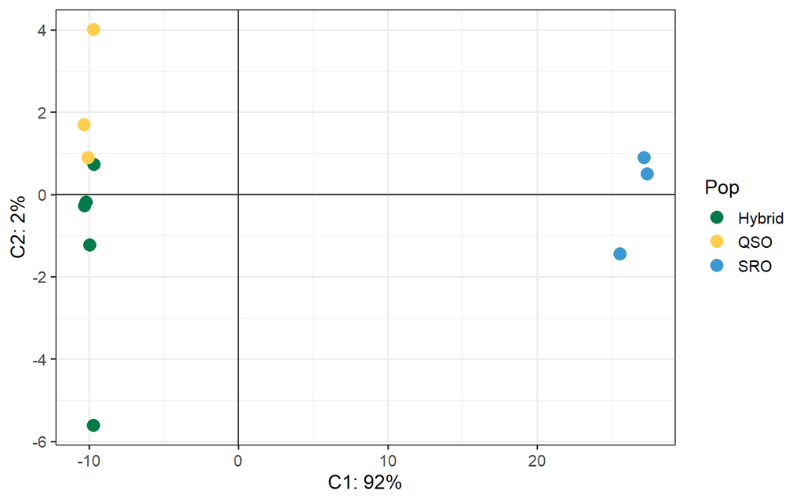

Figure 2.1: Principal component analysis based on 158 informative SNP loci in 11 oyster samples

```r
#PCA
#Convert to a genind object
filtered_vcf <- read.vcfR("output/Oyster_hybrids_filtered_vcf_informloci.vcf.gz",
                          verbose = FALSE)
vcf_samples <- colnames(filtered_vcf@gt)[-1]
popmap <- tibble(
  id = vcf_samples,
  pop = sub("_.+$", "", vcf_samples)
)
gen <- vcfR2genind(filtered_vcf)
allelfreq <- scaleGen(gen, NA.method="mean", scale=TRUE)

pca <- dudi.pca(allelfreq, scale = FALSE, scannf = FALSE, nf = 10)

#need the coordinated that each isolate exist on
# genind_df <- data.frame(id = indNames(gen))

pcadata <- pca$li %>% rownames_to_column('id') %>%
           left_join(popmap)
# calculate variance explained by PCs
pcavar <- pca$li %>% summarise(across(starts_with('Axis'), var))
percent_var <- pcavar/sum(pcavar)
# plot PCA
pop_levels <- length(unique(pcadata$pop))
# sample_levels <-
ggplot(pcadata, aes(x= Axis1, y= Axis2, colour = pop)) + geom_point(size = 4) +  scale_colour_paletteer_d("awtools::mpalette") +
  geom_hline(yintercept = 0) + geom_vline(xintercept = 0) +
  labs(colour = "Pop", x= glue("C1: {percent(percent_var$Axis1)}"),
       y= glue("C2: {percent(percent_var$Axis2)}")) +
  theme_bw(14)
```

## 2.2 General information

This document was last updated at 2025-08-05 02:02:40.595338 using R Markdown (built with R version 4.5.1 (2025-06-13 ucrt)). The source code for this webpage can be found at https://github.com/IdoBar/Oyster_hybrids_nanopore_seq (or via the GitHub logo at the top right corner of this page).

# Bibliography

Barbitoff YA, Abasov R, Tvorogova VE, et al. (2022) Systematic benchmark of state-of-the-art variant calling pipelines identifies major factors affecting accuracy of coding sequence variant discovery. Bmc Genomics 23:155. doi: 10.1186/s12864-022-08365-3

Cui M, Liu Y, Yu X, et al. (2024) miniSNV: accurate and fast single nucleotide variant calling from nanopore sequencing data. Briefings Bioinf 25:bbae473. doi: 10.1093/bib/bbae473

Danecek P, Auton A, Abecasis G, et al. (2011) The variant call format and VCFtools. Bioinformatics 27:2156–2158. doi: 10.1093/bioinformatics/btr330

Danecek P, Bonfield JK, Liddle J, et al. (2021) Twelve years of SAMtools and BCFtools. GigaScience 10:giab008. doi: 10.1093/gigascience/giab008

DeRaad DA (2022) snpfiltr: An R package for interactive and reproducible SNP filtering. Mol Ecol Resour 22:2443–2453. doi: 10.1111/1755-0998.13618

Jain C, Rhie A, Hansen NF, et al. (2022) Long-read mapping to repetitive reference sequences using Winnowmap2. Nat Methods 19:705–710. doi: 10.1038/s41592-022-01457-8

Jombart T (2008) adegenet: a R package for the multivariate analysis of genetic markers. Bioinformatics 24:1403–1405. doi: 10.1093/bioinformatics/btn129

Jombart T, Ahmed I (2011) adegenet 1.3-1: new tools for the analysis of genome-wide SNP data. Bioinformatics 27:3070–3071. doi: 10.1093/bioinformatics/btr521

Jombart T, Kamvar ZN, Collins C, et al. (2020) [adegenet: Exploratory analysis of genetic and genomic data](http://datacompass.lshtm.ac.uk/1765/).

Knaus BJ, Grünwald NJ (2017) vcfr: a package to manipulate and visualize variant call format data in R. Mol Ecol Resour 17:44–53. doi: 10.1111/1755-0998.12549

Lee S, Nguyen LT, Hayes BJ, Ross EM (2021) Prowler: a novel trimming algorithm for oxford nanopore sequence data. Bioinformatics 37:3936–3937. doi: 10.1093/bioinformatics/btab630

Li H (2018) Minimap2: pairwise alignment for nucleotide sequences. Bioinformatics 34:3094–3100. doi: 10.1093/bioinformatics/bty191

Li H (2021) New strategies to improve minimap2 alignment accuracy. Bioinformatics 37:4572–4574. doi: 10.1093/bioinformatics/btab705

Li H (2011) A statistical framework for SNP calling, mutation discovery, association mapping and population genetical parameter estimation from sequencing data. Bioinformatics 27:2987–2993. doi: 10.1093/bioinformatics/btr509

Ruden DM, Cingolani P, Patel VM, et al. (2012) Using *Drosophila melanogaster* as a model for genotoxic chemical mutational studies with a new program, SnpSift. Drosophila melanogaster 3:35. doi: 10.3389/fgene.2012.00035

Steinig E, Coin L (2022) Nanoq: ultra-fast quality control for nanopore reads. J Open Source Softw 7:2991. doi: 10.21105/joss.02991

Tange O (2011) GNU Parallel - The Command-Line Power Tool. ;login: The USENIX Magazine 36:42–47. doi: 10.5281/zenodo.16303

Tischler G, Leonard S (2014) biobambam: tools for read pair collation based algorithms on BAM files. Source Code Biol Med 9:13. doi: 10.1186/1751-0473-9-13

Vythalingam LM, Regan T, Bean T, Peñaloza C (2022) [CTAB DNA extraction protocol for mollusks](https://www.protocols.io/view/ctab-dna-extraction-protocol-for-mollusks-cf8ntrve).

Zheng Z, Li S, Su J, et al. (2022) Symphonizing pileup and full-alignment for deep learning-based long-read variant calling. Nat Comput Sci 2:797–803. doi: 10.1038/s43588-022-00387-x